# TU060 - Math 9102 – PSI - Portfolio - Analyse

Joseph O’Carroll

30/11/2020

# Comparing More than Two Groups Parametric

When testing for differences in more than two groups, again the choice of test we perform to investigate if differential effects exist for different groups depends on the measurement level of the variable and the shape of the data. If our data measurement level is at least interval data and normally distributed then we can use the parametric ANOVA test for independent variables or a variant of the ANOVA test for repeated measures. If our data is ordinal or is continuous scale data that does not conform to the normal distribution, then we use a non parametric test Kruskal-wallis for independent samples or Freidman for repeated measures.

Similar to the t-test, the ANOVA test is still based on the normal distribution and utilities the mean for each variable but it looks at the variance in the mean within each group and see hows that relates to variation between the groups. We start by looking at the overall mean for the variable of interest in our first calculation of F and then we look to see how different the groups means are from that.

In AVONA testing, the theory is that for the variable of interest for the multiple groups we’re investigating, if they are from the same population then the overall mean will be very close to the mean for each group and the variation around the mean for each group will be very similar. If we find that the group means and variance are different with regards to our significance level, then we can assume the groups are from different populations rather than one overall for the variable of interest.

ANOVA produces F-statistic. which is a ratio value. It is similar to t-score since it compares the amount of systematic variance in the data to the amount of unsystematic variance. In other words it compares what we see to what we expect for a distribution with the same degrees of freedom.

As such, it is the ratio of the variable of interest effect to the individual differences in performance. If the F=ratio’s value is less than 1, it represent a non-significant event and we accept the null hypothesis that there is only one population. If the F statistic is greater than 1, it indicates that there is some effect above and beyond the effect of individual differences in performance. To test for significance, we compare obtained F-ratio against maximum value one would expect to get by chance alone in an F-distribution with the same degrees of freedom. The p-value associated with F is probability that differences between groups could occur by chance if null-hypothesis is correct as such we’re aiming for a low p-value if we’re looking for evidence to support the alternative hypothesis. If our result is within the rejection region, it means that our f statistics is such that only 5% of samples from the same population for the variable of interest would produce the same T value, assuming two tailed significance levels of +/- 1.96. This is also known as a Type 1 error.

ANOVA tests for one overall effect only (this makes it an omnibus test), so it can tell us if experimental manipulation was generally successful. It doesn’t provide specific information about which specific groups were affected. To determine this we need to perform post-hoc testing!

# Parametric Difference testing with more than two groups

From the preparation phase we had the Hypothesis:

> Maternal educational achievement has a differential effect on student performance overall.

Using our student performance dataset we are going to investigate if there is a significant difference in the mean performance score for students whose mother’s obtain different levels of education achievement.

To do this difference test we have one independent/predictor/input variable that is considered a categorical variable. We will use the ordinal variable Medu representing mother’s education (0 – none, 1 – primary education (4th grade), 2 – 5th to 9th grade, 3 – secondary education or 4 – higher education.). We have one continuous variable dependent/response/outcome variable which meets the criteria of being at least interval data. Our goal is to use the Independent samples AVONA test to tell us if there is a significant difference between these 5 groups. The null hypothesis is that there is no difference in performance. The alternative hypothesis is that there is a difference based on mothers education. This will be a one-way between groups Anova test with a significance level of .05. Observations are independent because they came from different people.

The only remaining questions to answer before selecting the difference test to perform relate to Normality and Homoscedasticity and they are addressed below.

## Step 1 - Assessment of normality

If the variable of interest is normal then we can use ANOVA. The variable of interest being used to illustrate this methodology is Portuguese final grade, pG3 which has previously been established to follow the normal distribution once outliers have been removed.

## Step 2 Generate Summary Statistics Reporting

```r
############
# PART: Generate Summary Statistics Reporting
############
# Create a subset dataframe with just the variables of interest.
tbl_sperf_medu_diff <- tbl_sperf_all %>%
  filter(pG3 != 0) %>%
  select(Medu, contains('pG3'))
# -------------- Create summary statistics --------------- #
tbl_sperf_medu_diff_stats <-
  psych::describeBy(tbl_sperf_medu_diff,
                    tbl_sperf_medu_diff$Medu,
                    mat = TRUE)  %>%
  filter(!is.nan(skew)) # removes categorical variables.

# Pretty print table
tbl_sperf_medu_diff_stats %>%
  select(-(median)) %>% # Removing invalid statistics for this data type.
  kbl(caption = "Summary statistics for Grade (zero scores removed) by Mothers education level") %>%
  kable_styling(bootstrap_options = c("striped", "hover"))
```

Summary statistics for Grade (zero scores removed) by Mothers education level

|  | item | group1 | vars | n | mean | sd | trimmed | mad | min | max | range | skew | kurtosis | se |
| --- | --- | --- | --- | --- | --- | --- | --- | --- | --- | --- | --- | --- | --- | --- |
| pG31 | 6 | 0 | 2 | 3 | 12.33333 | 2.309401 | 12.33333 | 0.0000 | 11 | 15 | 4 | 0.3849002 | -2.3333333 | 1.3333333 |
| pG32 | 7 | 1 | 2 | 49 | 12.02041 | 2.609995 | 11.80488 | 2.9652 | 7 | 18 | 11 | 0.6531037 | 0.0995218 | 0.3728565 |
| pG33 | 8 | 2 | 2 | 97 | 12.13402 | 2.356855 | 12.12658 | 1.4826 | 6 | 18 | 12 | -0.0595605 | 0.2001724 | 0.2393024 |
| pG34 | 9 | 3 | 2 | 95 | 12.52632 | 2.949367 | 12.59740 | 2.9652 | 1 | 19 | 18 | -0.5567336 | 1.3561680 | 0.3025987 |
| pG35 | 10 | 4 | 2 | 133 | 13.44361 | 2.291002 | 13.42991 | 2.9652 | 8 | 19 | 11 | 0.0308614 | -0.4584421 | 0.1986551 |

## Step 2 Check for Homogeneity of Variance

Homogeneity of variance means that the pattern in variance of the variable around the mean for each group is the same. To assess homogeneity we use the Lavene test. The Lavene test works on the basis that the variance between the two groups is the same. As such if we run the Bartlett’s test and if we do not find a statistically significant (p value less than 0.025 for 95% significance level) result we can assume homogeneity of variance. The outcome of this test will determine what post-hoc test we will use.

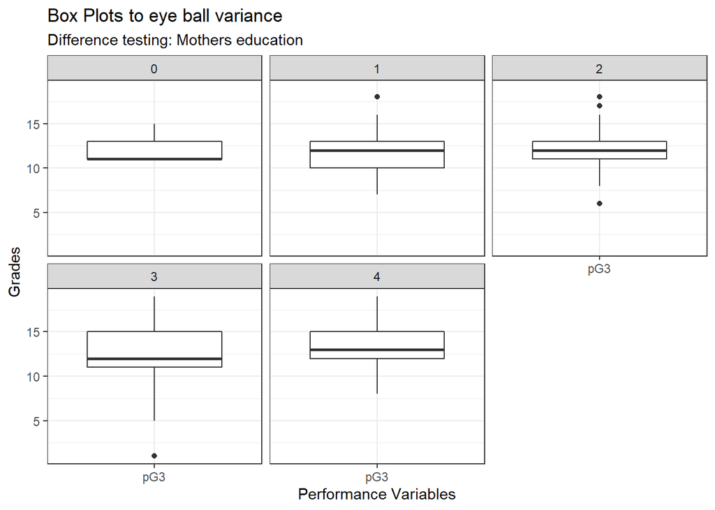

```r
############
# PART: Homoscedasticity
############

# -------------- Box Plot --------------- #
# Just a little eye ball test fo variance and mean to cross check with Leven's test
tbl_sperf_medu_diff %>%
  gather(pG3, key = "var", value = "value") %>%
  ggplot(aes(x = var, y = value, fill = value)) +
  geom_boxplot() +
  theme_bw() +
  labs(
    y = "Grades",
    x = "Performance Variables",
    title = "Box Plots to eye ball variance",
    subtitle = "Difference testing: Mothers education"
  ) + facet_wrap(~Medu)
```

```r
# -------------- Bartlett's test --------------- #
# Conduct Bartlett's test for homogeneity of variance in library car - the null hypothesis is that variances in groups are equal so to
# assume homogeneity we would expect probaility to not be statistically significant.
result <- list()
result[["pG1"]]                   <- stats::bartlett.test(pG3~ Medu, data=tbl_sperf_medu_diff)
```